# MSDS 430 Module 5 Exploratory Data Analysis (EDA)

**In this assignment you will read through the notebook and complete the exercises. Once you are satisfied with the results, submit your notebook and html file to Canvas. Your files should include all output, i.e. run each cell and save your file before submitting.**

**Research project problem statement:** Research project problem statement: A brewery has a number of signature beers that they produce and they want to expand their production in to different style of beer. They know what their market likes in beer, but what does the market in general rate highest? What are the top breweries based on ratings making? What are the top styles? What else are you able to tell them about the top rated beers? They are thinking about a seasonal beer but are not sure if seasonal beers are rated highly? You will use a number of EDA techniques to answer these questions and many more.

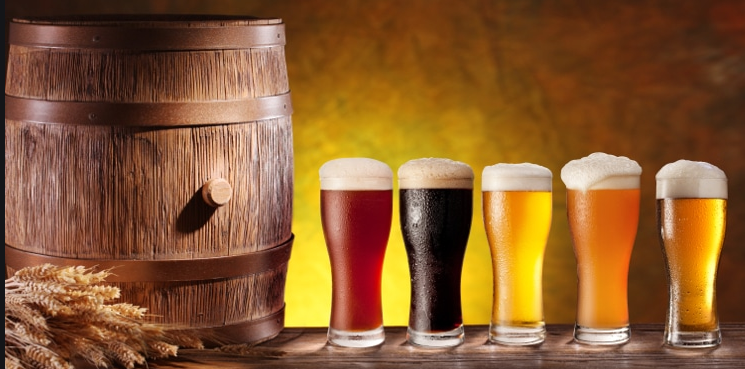

**In many of the problems you will see #TODO statements added as comments on the code cell provided. You will want to be sure to complete each of these as indicated to avoid losing points.**

```python
# https://jakevdp.github.io/blog/2017/12/05/installing-python-packages-from-jupyter/
# import sys
# !conda update --yes --prefix {sys.prefix} seaborn
```

```python
# load up modules
import pandas as pd
import numpy as np
import re
import seaborn as sns

# set up notebook to display multiple output in one cell
from IPython.core.interactiveshell import InteractiveShell
InteractiveShell.ast_node_interactivity = "all"
```

## Part 1: Load the Datasets

- We are going to work with the following two sets of data:

  ```
    1. 'open-beer-database.csv'
    2. 'beer_reviews.csv'
  ```

Source 1: https://data.opendatasoft.com/explore/dataset/open-beer-database%40public-us/table/

Source 2: https://www.kaggle.com/rdoume/beerreviews

### Load 'open_beer_database.csv' and take a peek at the data

- Load the data in the file "open_beer_database.csv" into a dataframe and save it to the a variable named `beers`.
- View the data as follows:

  ```
    the total numbers of rows and columns
    the first (or last) few rows
    the column names
  ```

- Generate descriptive statistics of the dataframe using the pandas `describe()` method.
- Use `boxplots` to detect outliers.

```python
!kaggle datasets download -d rdoume/beerreviews
!unzip beerreviews.zip
!rm beerreviews.zip
!wget --output-document='open-beer-database.csv' 'https://ppival.opendatasoft.com/api/v2/catalog/datasets/beer/exports/csv?select=%2A&limit=-1&offset=0&lang=en&timezone=UTC'
!ls
```

```
Downloading beerreviews.zip to /home/mike/git/MSDS_430/Module5
Archive:  beerreviews.zip
  inflating: beer_reviews.csv
--2022-10-23 22:39:45--  https://ppival.opendatasoft.com/api/v2/catalog/datasets/beer/exports/csv?select=%2A&limit=-1&offset=0&lang=en&timezone=UTC
Resolving ppival.opendatasoft.com (ppival.opendatasoft.com)... 34.196.27.91, 52.1.105.32
Connecting to ppival.opendatasoft.com (ppival.opendatasoft.com)|34.196.27.91|:443... connected.
HTTP request sent, awaiting response... 200 OK
Length: unspecified [text/csv]
Saving to: ‘open-beer-database.csv’

open-beer-database.     [ <=>                ]  45.77K  --.-KB/s    in 0.03s

2022-10-23 22:39:45 (1.53 MB/s) - ‘open-beer-database.csv’ saved [46868]

beer_reviews.csv  Module_5_Python_Assignment.ipynb  open-beer-database.csv
```

```python
beers=pd.read_csv("beer_reviews.csv")
```

```python
beers.describe()

beers.describe(include=['O'])
```

|  | brewery_id | review_time | review_overall | review_aroma | review_appearance | review_palate | review_taste | beer_abv | beer_beerid |
| --- | --- | --- | --- | --- | --- | --- | --- | --- | --- |
| count | 1.586614e+06 | 1.586614e+06 | 1.586614e+06 | 1.586614e+06 | 1.586614e+06 | 1.586614e+06 | 1.586614e+06 | 1.518829e+06 | 1.586614e+06 |
| mean | 3.130099e+03 | 1.224089e+09 | 3.815581e+00 | 3.735636e+00 | 3.841642e+00 | 3.743701e+00 | 3.792860e+00 | 7.042387e+00 | 2.171279e+04 |
| std | 5.578104e+03 | 7.654427e+07 | 7.206219e-01 | 6.976167e-01 | 6.160928e-01 | 6.822184e-01 | 7.319696e-01 | 2.322526e+00 | 2.181834e+04 |
| min | 1.000000e+00 | 8.406720e+08 | 0.000000e+00 | 1.000000e+00 | 0.000000e+00 | 1.000000e+00 | 1.000000e+00 | 1.000000e-02 | 3.000000e+00 |
| 25% | 1.430000e+02 | 1.173224e+09 | 3.500000e+00 | 3.500000e+00 | 3.500000e+00 | 3.500000e+00 | 3.500000e+00 | 5.200000e+00 | 1.717000e+03 |
| 50% | 4.290000e+02 | 1.239203e+09 | 4.000000e+00 | 4.000000e+00 | 4.000000e+00 | 4.000000e+00 | 4.000000e+00 | 6.500000e+00 | 1.390600e+04 |
| 75% | 2.372000e+03 | 1.288568e+09 | 4.500000e+00 | 4.000000e+00 | 4.000000e+00 | 4.000000e+00 | 4.500000e+00 | 8.500000e+00 | 3.944100e+04 |
| max | 2.800300e+04 | 1.326285e+09 | 5.000000e+00 | 5.000000e+00 | 5.000000e+00 | 5.000000e+00 | 5.000000e+00 | 5.770000e+01 | 7.731700e+04 |

|  | brewery_name | review_profilename | beer_style | beer_name |
| --- | --- | --- | --- | --- |
| count | 1586599 | 1586266 | 1586614 | 1586614 |
| unique | 5742 | 33387 | 104 | 56857 |
| top | Boston Beer Company (Samuel Adams) | northyorksammy | American IPA | 90 Minute IPA |
| freq | 39444 | 5817 | 117586 | 3290 |

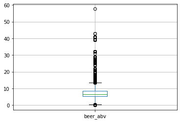

```python
beers.boxplot(column='beer_abv')
```

### Load `beer_reviews.csv` and take a peek at the data

- Load the data in the file "beer_reviews.csv" into a dataframe and save it to a variable named `beer_reviews`.
- View the data as follows:

  ```
    the total numbers of rows and columns
    the first (or last) few rows
    the column names
  ```

**Problem 1 (5 pts.)**: Read 'beer_reviews.csv" into Python just like we did with the 'open-beer-database.csv' file and assign the dataframe to the variable *beer_reviews*. Note that this time the fields in the csv are separated by commas (the default separator).  
Also (a) display the shape, (b) the first five records, (c) the columns of *beer_reviews* and (d) the descriptive statistics. Finally, (e) create a boxplot to detect outliers in each of the review rating categories.

```python
# TODO:  read 'beer_reviews.csv" into Python and assign the dataframe to the variable "beer_reviews".
beer_reviews = pd.read_csv("beer_reviews.csv")

# TODO: determine the shape of the data
print(beer_reviews.shape)

# TODO: display the first five records
beer_reviews.head(5)

# TODO: use describe() to display descriptive statistics about the data
print(beer_reviews.describe())
```

```
(1586614, 13)
```

|  | brewery_id | brewery_name | review_time | review_overall | review_aroma | review_appearance | review_profilename | beer_style | review_palate | review_taste | beer_name | beer_abv | beer_beerid |
| --- | --- | --- | --- | --- | --- | --- | --- | --- | --- | --- | --- | --- | --- |
| 0 | 10325 | Vecchio Birraio | 1234817823 | 1.5 | 2.0 | 2.5 | stcules | Hefeweizen | 1.5 | 1.5 | Sausa Weizen | 5.0 | 47986 |
| 1 | 10325 | Vecchio Birraio | 1235915097 | 3.0 | 2.5 | 3.0 | stcules | English Strong Ale | 3.0 | 3.0 | Red Moon | 6.2 | 48213 |
| 2 | 10325 | Vecchio Birraio | 1235916604 | 3.0 | 2.5 | 3.0 | stcules | Foreign / Export Stout | 3.0 | 3.0 | Black Horse Black Beer | 6.5 | 48215 |
| 3 | 10325 | Vecchio Birraio | 1234725145 | 3.0 | 3.0 | 3.5 | stcules | German Pilsener | 2.5 | 3.0 | Sausa Pils | 5.0 | 47969 |
| 4 | 1075 | Caldera Brewing Company | 1293735206 | 4.0 | 4.5 | 4.0 | johnmichaelsen | American Double / Imperial IPA | 4.0 | 4.5 | Cauldron DIPA | 7.7 | 64883 |

```
         brewery_id   review_time  review_overall  review_aroma  \
count  1.586614e+06  1.586614e+06    1.586614e+06  1.586614e+06
mean   3.130099e+03  1.224089e+09    3.815581e+00  3.735636e+00
std    5.578104e+03  7.654427e+07    7.206219e-01  6.976167e-01
min    1.000000e+00  8.406720e+08    0.000000e+00  1.000000e+00
25%    1.430000e+02  1.173224e+09    3.500000e+00  3.500000e+00
50%    4.290000e+02  1.239203e+09    4.000000e+00  4.000000e+00
75%    2.372000e+03  1.288568e+09    4.500000e+00  4.000000e+00
max    2.800300e+04  1.326285e+09    5.000000e+00  5.000000e+00

       review_appearance  review_palate  review_taste      beer_abv  \
count       1.586614e+06   1.586614e+06  1.586614e+06  1.518829e+06
mean        3.841642e+00   3.743701e+00  3.792860e+00  7.042387e+00
std         6.160928e-01   6.822184e-01  7.319696e-01  2.322526e+00
min         0.000000e+00   1.000000e+00  1.000000e+00  1.000000e-02
25%         3.500000e+00   3.500000e+00  3.500000e+00  5.200000e+00
50%         4.000000e+00   4.000000e+00  4.000000e+00  6.500000e+00
75%         4.000000e+00   4.000000e+00  4.500000e+00  8.500000e+00
max         5.000000e+00   5.000000e+00  5.000000e+00  5.770000e+01

        beer_beerid
count  1.586614e+06
mean   2.171279e+04
std    2.181834e+04
min    3.000000e+00
25%    1.717000e+03
50%    1.390600e+04
75%    3.944100e+04
max    7.731700e+04
```

```python
# TODO: list the columns
beer_reviews.columns
```

```
Index(['brewery_id', 'brewery_name', 'review_time', 'review_overall',
       'review_aroma', 'review_appearance', 'review_profilename', 'beer_style',
       'review_palate', 'review_taste', 'beer_name', 'beer_abv',
       'beer_beerid'],
      dtype='object')
```

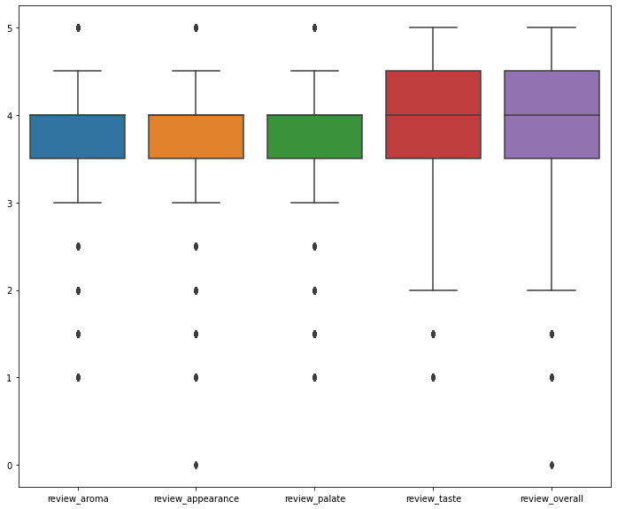

```python
# TODO: create a side-by-side boxplot that contains boxplots for aroma, appearance, palate, taste, and overall
import matplotlib.pyplot as plt

fig, ax = plt.subplots(figsize=(12,10))
sns.boxplot(data=beer_reviews[['review_aroma', 'review_appearance', 'review_palate', 'review_taste', 'review_overall']])
plt.show()
```

## Part 2: Inspect the Data

### Using `info( )` to inspect the two dataframes

- For each dataframe, we use the pandas function `info()` to display the column names (variables), their data types, and the number of non-null values in each column.
- We will also see what common variables (containing the same information) the two dataframes share.

**Observations from the output:**

```python
beers.info()
```

```
<class 'pandas.core.frame.DataFrame'>
RangeIndex: 1586614 entries, 0 to 1586613
Data columns (total 13 columns):
 #   Column              Non-Null Count    Dtype
---  ------              --------------    -----
 0   brewery_id          1586614 non-null  int64
 1   brewery_name        1586599 non-null  object
 2   review_time         1586614 non-null  int64
 3   review_overall      1586614 non-null  float64
 4   review_aroma        1586614 non-null  float64
 5   review_appearance   1586614 non-null  float64
 6   review_profilename  1586266 non-null  object
 7   beer_style          1586614 non-null  object
 8   review_palate       1586614 non-null  float64
 9   review_taste        1586614 non-null  float64
 10  beer_name           1586614 non-null  object
 11  beer_abv            1518829 non-null  float64
 12  beer_beerid         1586614 non-null  int64
dtypes: float64(6), int64(3), object(4)
memory usage: 157.4+ MB
```

**Problem 2 (1 pt.)**: Apply the *info( )* method to *beer_reviews* like we did with the *beers* DataFrame object.

```python
# TODO: use the info() method to inspect the data
beer_reviews.info()
```

```
<class 'pandas.core.frame.DataFrame'>
RangeIndex: 1586614 entries, 0 to 1586613
Data columns (total 13 columns):
 #   Column              Non-Null Count    Dtype
---  ------              --------------    -----
 0   brewery_id          1586614 non-null  int64
 1   brewery_name        1586599 non-null  object
 2   review_time         1586614 non-null  int64
 3   review_overall      1586614 non-null  float64
 4   review_aroma        1586614 non-null  float64
 5   review_appearance   1586614 non-null  float64
 6   review_profilename  1586266 non-null  object
 7   beer_style          1586614 non-null  object
 8   review_palate       1586614 non-null  float64
 9   review_taste        1586614 non-null  float64
 10  beer_name           1586614 non-null  object
 11  beer_abv            1518829 non-null  float64
 12  beer_beerid         1586614 non-null  int64
dtypes: float64(6), int64(3), object(4)
memory usage: 157.4+ MB
```

### Using `isnull( ).sum( )` to display the number of missing values in each column

- For each dataframe, we use `isnull().sum()` to displays the number of missing values in each column.
- `df.isnull()` returns a copy of the dataframe `df` with the null (i.e. `NaN`) values replaced by `True` and the nonnull values replaced by `False`. Since the Boolean values `True` and `False` are implemented as `1` and `0`, respectively, in Python, the sum of the Boolean values in each column of `df`(obtained by applying `sum()`) is the number of missing values in each column of `df`.

**Observations from the output:**

```python
beers.isnull().head()
beers.isnull().sum()
beer_reviews.isnull().sum()
```

|  | brewery_id | brewery_name | review_time | review_overall | review_aroma | review_appearance | review_profilename | beer_style | review_palate | review_taste | beer_name | beer_abv | beer_beerid |
| --- | --- | --- | --- | --- | --- | --- | --- | --- | --- | --- | --- | --- | --- |
| 0 | False | False | False | False | False | False | False | False | False | False | False | False | False |
| 1 | False | False | False | False | False | False | False | False | False | False | False | False | False |
| 2 | False | False | False | False | False | False | False | False | False | False | False | False | False |
| 3 | False | False | False | False | False | False | False | False | False | False | False | False | False |
| 4 | False | False | False | False | False | False | False | False | False | False | False | False | False |

```
brewery_id                0
brewery_name             15
review_time               0
review_overall            0
review_aroma              0
review_appearance         0
review_profilename      348
beer_style                0
review_palate             0
review_taste              0
beer_name                 0
beer_abv              67785
beer_beerid               0
dtype: int64
```

```
brewery_id                0
brewery_name             15
review_time               0
review_overall            0
review_aroma              0
review_appearance         0
review_profilename      348
beer_style                0
review_palate             0
review_taste              0
beer_name                 0
beer_abv              67785
beer_beerid               0
dtype: int64
```

### Using `unique( )` to find the *different* beers in each dataframe

- Note that the number of rows in the `beers` dataframe is not the number of different beers since some of the beers are listed multiple times. To find the different beers included in the `beers` dataframe, we use the `unique()` function on the **Name** variable (column). Similar, we use `nunique()` to find the number of different beer names.
- Similarly, we use the `nunique()` function on the `beer_name` variable in the beer_reviews dataframe to find the number of different beers reviewed in the dataframe.

**Observations from the output:**

```python
beers.beer_name.unique().shape

beer_reviews.beer_name.unique().shape  # or beer_reviews.beer_name.nunique()
```

```
(56857,)
```

```
(56857,)
```

### Selecting rows with Boolean filtering

```python
beers
```

|  | brewery_id | brewery_name | review_time | review_overall | review_aroma | review_appearance | review_profilename | beer_style | review_palate | review_taste | beer_name | beer_abv | beer_beerid |
| --- | --- | --- | --- | --- | --- | --- | --- | --- | --- | --- | --- | --- | --- |
| 0 | 10325 | Vecchio Birraio | 1234817823 | 1.5 | 2.0 | 2.5 | stcules | Hefeweizen | 1.5 | 1.5 | Sausa Weizen | 5.0 | 47986 |
| 1 | 10325 | Vecchio Birraio | 1235915097 | 3.0 | 2.5 | 3.0 | stcules | English Strong Ale | 3.0 | 3.0 | Red Moon | 6.2 | 48213 |
| 2 | 10325 | Vecchio Birraio | 1235916604 | 3.0 | 2.5 | 3.0 | stcules | Foreign / Export Stout | 3.0 | 3.0 | Black Horse Black Beer | 6.5 | 48215 |
| 3 | 10325 | Vecchio Birraio | 1234725145 | 3.0 | 3.0 | 3.5 | stcules | German Pilsener | 2.5 | 3.0 | Sausa Pils | 5.0 | 47969 |
| 4 | 1075 | Caldera Brewing Company | 1293735206 | 4.0 | 4.5 | 4.0 | johnmichaelsen | American Double / Imperial IPA | 4.0 | 4.5 | Cauldron DIPA | 7.7 | 64883 |
| ... | ... | ... | ... | ... | ... | ... | ... | ... | ... | ... | ... | ... | ... |
| 1586609 | 14359 | The Defiant Brewing Company | 1162684892 | 5.0 | 4.0 | 3.5 | maddogruss | Pumpkin Ale | 4.0 | 4.0 | The Horseman's Ale | 5.2 | 33061 |
| 1586610 | 14359 | The Defiant Brewing Company | 1161048566 | 4.0 | 5.0 | 2.5 | yelterdow | Pumpkin Ale | 2.0 | 4.0 | The Horseman's Ale | 5.2 | 33061 |
| 1586611 | 14359 | The Defiant Brewing Company | 1160702513 | 4.5 | 3.5 | 3.0 | TongoRad | Pumpkin Ale | 3.5 | 4.0 | The Horseman's Ale | 5.2 | 33061 |
| 1586612 | 14359 | The Defiant Brewing Company | 1160023044 | 4.0 | 4.5 | 4.5 | dherling | Pumpkin Ale | 4.5 | 4.5 | The Horseman's Ale | 5.2 | 33061 |
| 1586613 | 14359 | The Defiant Brewing Company | 1160005319 | 5.0 | 4.5 | 4.5 | cbl2 | Pumpkin Ale | 4.5 | 4.5 | The Horseman's Ale | 5.2 | 33061 |

1586614 rows × 13 columns

**Problem 3 (2 pts.):** Use Boolean filtering to select the rows in the *beer_reviews* dataframe where the *beer_abv* values are missing and save this new dataframe to a variable named *missing_abv*. Also determine the number of different beers with missing abv values.

```python
# TODO: use Boolean filtering to select rows where beer_abv values are missing and assign this to missing_abv
missing_abv=beer_reviews[beer_reviews['beer_abv'].isnull()==True]

# TODO: use the nunique() method to determine the number of different beers with missing_abv values
missing_abv['beer_name'].nunique()
```

```
14110
```

## Part 3: Prepare the Data

**For the data preparation part, we will conduct the following three tasks:**

1. Eliminating columns that contain no useful information
2. Transforming time data to the standard datetime format
3. Handling missing values

**How to handle missing values**

- Here are the two common methods:
  1. Deleting rows with missing values
  2. Replacing missing values with a special value such Mean/Median/Mode or an unique category

**How we handle the missing brewery names in the `beer_reviews` dataframe**

**We will use the following functions to accomplish our tasks:**

1. Dropping the unusable columns using `drop()`
2. Transforming time data using `to_datetime()`
3. Filling missing values using `replace()` and `fillna()`
4. Dropping missing values using `dropna()`

### Using `drop( )` to eliminate columns

- Let's eliminate the columns we know for sure we will not use.
- From the `beers` dataframe, we will drop the following columns: **id**, **brewery_id**, **Standard Reference Method**, **Universal Product Code**, **filepath**, **Description**, **add_user**, **last_mod**, and **Website**. After we drop these columns we will save the new dataframe as `beers2` and use the new dataframe from now on.
- From the `beer_reviews` dataframe, we will drop the two columns: **brewery_id** and **beer_beerid**. After we drop the columns, we will save the new dataframe as `beer_reviews2` and use the new dataframe from now on.
- We can eliminate more later if EDA shows they will not help our analysis.

```python
### it looks like the datasets have been updated since this assignment was made. I am going to try to drop each of these columns.

col_to_drop = ['id','brewery_id','Standard Reference Method','Universal Product Code',
            'filepath', 'Description', 'add_user','last_mod', 'Website']

beers2=beers.copy()
for i in col_to_drop:
    try:
        beers2 = beers2.drop(columns=i, inplace=False)
    except:
        pass
beers2.info()
```

```
<class 'pandas.core.frame.DataFrame'>
RangeIndex: 1586614 entries, 0 to 1586613
Data columns (total 12 columns):
 #   Column              Non-Null Count    Dtype
---  ------              --------------    -----
 0   brewery_name        1586599 non-null  object
 1   review_time         1586614 non-null  int64
 2   review_overall      1586614 non-null  float64
 3   review_aroma        1586614 non-null  float64
 4   review_appearance   1586614 non-null  float64
 5   review_profilename  1586266 non-null  object
 6   beer_style          1586614 non-null  object
 7   review_palate       1586614 non-null  float64
 8   review_taste        1586614 non-null  float64
 9   beer_name           1586614 non-null  object
 10  beer_abv            1518829 non-null  float64
 11  beer_beerid         1586614 non-null  int64
dtypes: float64(6), int64(2), object(4)
memory usage: 145.3+ MB
```

**Problem 4 (2 pts.):** Drop the "brewery_id" and "beer_beerid" columns from *beer_reviews* and save the new dataframe as "beer_reviews2". Finally, use **info( )** to display a concise summary of the new dataframe.

```python
# TODO: create a new dataframe called 'beer_reviews2' that uses the drop() method to remove the columns
#      'brewery_id' and 'beerid'
### it looks like the datasets have been updated since this assignment was made. I am going to try to drop each of these columns.

col_to_drop2 = ['beerid','brewery_id']

beer_reviews2=beer_reviews.copy()
for i in col_to_drop2:
    try:
        beer_reviews2 = beers.drop(columns=i, inplace=False)
    except:
        pass


# TODO: use the info() method to display a summary of 'beer_reviews2'
beer_reviews2.info()
```

```
<class 'pandas.core.frame.DataFrame'>
RangeIndex: 1586614 entries, 0 to 1586613
Data columns (total 12 columns):
 #   Column              Non-Null Count    Dtype
---  ------              --------------    -----
 0   brewery_name        1586599 non-null  object
 1   review_time         1586614 non-null  int64
 2   review_overall      1586614 non-null  float64
 3   review_aroma        1586614 non-null  float64
 4   review_appearance   1586614 non-null  float64
 5   review_profilename  1586266 non-null  object
 6   beer_style          1586614 non-null  object
 7   review_palate       1586614 non-null  float64
 8   review_taste        1586614 non-null  float64
 9   beer_name           1586614 non-null  object
 10  beer_abv            1518829 non-null  float64
 11  beer_beerid         1586614 non-null  int64
dtypes: float64(6), int64(2), object(4)
memory usage: 145.3+ MB
```

### Using `to_datetime( )` to transform "unix time" data to the standard date values

- Note that the time data in the `review_time` column are "Unix times" so we need to covert them to the standard datetime values.
- We will add a new column named `review_date` to hold the transformed `review_time`.
- We will also use the pandas `value_counts()` function to display all the unique values with their counts.

In this example we show how to convert integer values in a column that represent the number of seconds that have elapsed since the "Unix epoch", i.e. `00:00:00 UTC on 1 January 1970`. Unix time is widely used in operating systems and file formats (including `beer_reviews.csv`) and one should now how to convert these values to a more useful representation. Luckily, pandas provides some methods for doing this conversion starting with `pd.to_datetime`.  
See https://pandas.pydata.org/pandas-docs/stable/reference/api/pandas.to_datetime.html.  
The values returned by `pd.to_datetime` are of type `Timestamp`. We then use the `dt.date` Series method to extract the date part of Timestamps without timezone information.  
See https://pandas.pydata.org/pandas-docs/stable/reference/api/pandas.Series.dt.date.html

First we create a series with "Unix time" values.

```python
time_series = pd.Series([1234817823, 1235915097, 1235916604, 1234725145, 1293735206])
time_series
```

```
0    1234817823
1    1235915097
2    1235916604
3    1234725145
4    1293735206
dtype: int64
```

The pd.to_datetime(...) methods converts such a value to a Timestamp object.

```python
pd.to_datetime(1234817823,unit='s')  # The integer represents seconds elapsed..
```

```
Timestamp('2009-02-16 20:57:03')
```

This method can be applied to all the values in the series at once...

```python
pd.to_datetime(time_series, unit='s')
```

```
0   2009-02-16 20:57:03
1   2009-03-01 13:44:57
2   2009-03-01 14:10:04
3   2009-02-15 19:12:25
4   2010-12-30 18:53:26
dtype: datetime64[ns]
```

We can follow it by dt.date to extract just the date from the timestamp (dropping the time).

```python
pd.to_datetime(time_series, unit='s').dt.date
```

```
0    2009-02-16
1    2009-03-01
2    2009-03-01
3    2009-02-15
4    2010-12-30
dtype: object
```

**Problem 5 (3 pts.):** Convert the values in the "review_time" column of the "beer_reviews2" dataframe to dates. Create a new "review_date" column in "beer_reviews2" with these date values and then drop the "review_time" column.  
Use "value_counts( )" to display the 5 dates with the most reviews.

```python
beer_reviews2
```

|  | brewery_name | review_time | review_overall | review_aroma | review_appearance | review_profilename | beer_style | review_palate | review_taste | beer_name | beer_abv | beer_beerid |
| --- | --- | --- | --- | --- | --- | --- | --- | --- | --- | --- | --- | --- |
| 0 | Vecchio Birraio | 1234817823 | 1.5 | 2.0 | 2.5 | stcules | Hefeweizen | 1.5 | 1.5 | Sausa Weizen | 5.0 | 47986 |
| 1 | Vecchio Birraio | 1235915097 | 3.0 | 2.5 | 3.0 | stcules | English Strong Ale | 3.0 | 3.0 | Red Moon | 6.2 | 48213 |
| 2 | Vecchio Birraio | 1235916604 | 3.0 | 2.5 | 3.0 | stcules | Foreign / Export Stout | 3.0 | 3.0 | Black Horse Black Beer | 6.5 | 48215 |
| 3 | Vecchio Birraio | 1234725145 | 3.0 | 3.0 | 3.5 | stcules | German Pilsener | 2.5 | 3.0 | Sausa Pils | 5.0 | 47969 |
| 4 | Caldera Brewing Company | 1293735206 | 4.0 | 4.5 | 4.0 | johnmichaelsen | American Double / Imperial IPA | 4.0 | 4.5 | Cauldron DIPA | 7.7 | 64883 |
| ... | ... | ... | ... | ... | ... | ... | ... | ... | ... | ... | ... | ... |
| 1586609 | The Defiant Brewing Company | 1162684892 | 5.0 | 4.0 | 3.5 | maddogruss | Pumpkin Ale | 4.0 | 4.0 | The Horseman's Ale | 5.2 | 33061 |
| 1586610 | The Defiant Brewing Company | 1161048566 | 4.0 | 5.0 | 2.5 | yelterdow | Pumpkin Ale | 2.0 | 4.0 | The Horseman's Ale | 5.2 | 33061 |
| 1586611 | The Defiant Brewing Company | 1160702513 | 4.5 | 3.5 | 3.0 | TongoRad | Pumpkin Ale | 3.5 | 4.0 | The Horseman's Ale | 5.2 | 33061 |
| 1586612 | The Defiant Brewing Company | 1160023044 | 4.0 | 4.5 | 4.5 | dherling | Pumpkin Ale | 4.5 | 4.5 | The Horseman's Ale | 5.2 | 33061 |
| 1586613 | The Defiant Brewing Company | 1160005319 | 5.0 | 4.5 | 4.5 | cbl2 | Pumpkin Ale | 4.5 | 4.5 | The Horseman's Ale | 5.2 | 33061 |

1586614 rows × 12 columns

```python
# TODO:  from the beer_reviews2 dataframe, create a new column 'review_date' that converts the time data in the
#        'review_time' column to the standard datetime YYYY-MM-DD
beer_reviews2['review_date']=pd.to_datetime(beer_reviews2['review_time'], unit='s').dt.date


# TODO: use the drop method to remove the review_time column
beer_reviews2=beer_reviews2.drop(columns=['review_time'], inplace=False)


# TODO: use value_counts() to display the 5 dates with the most reviews
beer_reviews2['review_date'].value_counts()[0:5]
```

```
2011-02-13    1300
2011-02-26    1232
2011-08-27    1223
2012-01-08    1208
2010-12-23    1191
Name: review_date, dtype: int64
```

### Using `drop( )` to drop rows with missing names in `beers2`

- We will drop the null values from the columns: **Name**, **Brewer**, **Style**, **Category**
- Before we do this, we want to know how many rows with missing values in these columns and display these rows.

```python
beers2
```

|  | brewery_name | review_time | review_overall | review_aroma | review_appearance | review_profilename | beer_style | review_palate | review_taste | beer_name | beer_abv | beer_beerid |
| --- | --- | --- | --- | --- | --- | --- | --- | --- | --- | --- | --- | --- |
| 0 | Vecchio Birraio | 1234817823 | 1.5 | 2.0 | 2.5 | stcules | Hefeweizen | 1.5 | 1.5 | Sausa Weizen | 5.0 | 47986 |
| 1 | Vecchio Birraio | 1235915097 | 3.0 | 2.5 | 3.0 | stcules | English Strong Ale | 3.0 | 3.0 | Red Moon | 6.2 | 48213 |
| 2 | Vecchio Birraio | 1235916604 | 3.0 | 2.5 | 3.0 | stcules | Foreign / Export Stout | 3.0 | 3.0 | Black Horse Black Beer | 6.5 | 48215 |
| 3 | Vecchio Birraio | 1234725145 | 3.0 | 3.0 | 3.5 | stcules | German Pilsener | 2.5 | 3.0 | Sausa Pils | 5.0 | 47969 |
| 4 | Caldera Brewing Company | 1293735206 | 4.0 | 4.5 | 4.0 | johnmichaelsen | American Double / Imperial IPA | 4.0 | 4.5 | Cauldron DIPA | 7.7 | 64883 |
| ... | ... | ... | ... | ... | ... | ... | ... | ... | ... | ... | ... | ... |
| 1586609 | The Defiant Brewing Company | 1162684892 | 5.0 | 4.0 | 3.5 | maddogruss | Pumpkin Ale | 4.0 | 4.0 | The Horseman's Ale | 5.2 | 33061 |
| 1586610 | The Defiant Brewing Company | 1161048566 | 4.0 | 5.0 | 2.5 | yelterdow | Pumpkin Ale | 2.0 | 4.0 | The Horseman's Ale | 5.2 | 33061 |
| 1586611 | The Defiant Brewing Company | 1160702513 | 4.5 | 3.5 | 3.0 | TongoRad | Pumpkin Ale | 3.5 | 4.0 | The Horseman's Ale | 5.2 | 33061 |
| 1586612 | The Defiant Brewing Company | 1160023044 | 4.0 | 4.5 | 4.5 | dherling | Pumpkin Ale | 4.5 | 4.5 | The Horseman's Ale | 5.2 | 33061 |
| 1586613 | The Defiant Brewing Company | 1160005319 | 5.0 | 4.5 | 4.5 | cbl2 | Pumpkin Ale | 4.5 | 4.5 | The Horseman's Ale | 5.2 | 33061 |

1586614 rows × 12 columns

```python
#### there is no category per the new dataset so I am dropping it from the code.
beers2.beer_name.isnull().sum()
missing_beers = beers2[beers2.beer_name.isnull()][['beer_name','brewery_name','beer_style']]
missing_beers
```

```
0
```

|  | beer_name | brewery_name | beer_style |
| --- | --- | --- | --- |

```python
# Dropped the 10 rows...
beers2.shape
beers2 = beers2.drop(missing_beers.index)
beers2.shape
```

```
(1586614, 12)
```

```
(1586614, 12)
```

### Dealing with missing brewery names in `beer_reviews2`

#### Step 1: Get the names of beers in the reviews with missing brewery names.

- First we use `isnull().sum()` on the `brewer_name` column to find the number of beers with missing brewery names.
- Then we display the different names of these beers using `unique()`.

**Observations from the output:**

```python
# Find the number of beers with missing brewery names:
beer_reviews2.brewery_name.isnull().sum()

# Display the names of these beers:
beer_reviews_missing = beer_reviews2[beer_reviews2.brewery_name.isnull()]
beer_reviews_missing.beer_name.value_counts()
```

```
15
```

```
Engel Keller Dunkel  WRONG BREWERY SEE CRAILSHEIMER       3
Side Pocket                                               2
Breakaway IPA                                             2
Engel Tyrolian Bräu WRONG BREWERY SEE SCHWABISCH GMUND    1
Engel Bock Dunkel WRONG BREWERY SEE CRAILSHEIMER          1
Engel Gold WRONG BREWERY SEE CRAILSHEIMER                 1
Engel Landbier WRONG BREWERY SEE CRAILSHEIMER             1
Engel Keller Hell WRONG BREWERY SEE CRAILSHEIMER          1
Engel Aloisius - WRONG BREWERY SEE CRAILSHEIMER           1
Hard Hat American Beer                                    1
Caboose Oatmeal Stout                                     1
Name: beer_name, dtype: int64
```

#### Step 2: Find the brewery associated with "CRAILSHEIMER" and use it to replace the missing brewery name.

- First we want to see how many beers whose name contains the substring **"CRAILSHEIMER"** in the `beer_reviews_missing` dataframe.
- Then we search the breweries whose name contains the substring **"CRAILSHEIMER"** in the `beer_reviews2` dataframe. In the searching we ignore case by setting `flags=re.IGNORECASE`.

**Observations from the output:**

```python
#  beer_reviews_missing[beer_reviews_missing.beer_name.str.contains('CRAILSHEIMER')]
beer_reviews2.brewery_name.str.contains('CRAILSHEIMER',flags=re.IGNORECASE,na=False).sum()
```

```
54
```

```python
df=beer_reviews2[beer_reviews2.brewery_name.str.contains('CRAILSHEIMER',flags=re.IGNORECASE,na=False)]
df
```

|  | brewery_name | review_overall | review_aroma | review_appearance | review_profilename | beer_style | review_palate | review_taste | beer_name | beer_abv | beer_beerid | review_date |
| --- | --- | --- | --- | --- | --- | --- | --- | --- | --- | --- | --- | --- |
| 841865 | Crailsheimer Engelbräu | 3.5 | 3.0 | 3.5 | Globetrotter | Vienna Lager | 3.0 | 3.5 | Engel First Lady | 6.2 | 15824 | 2004-02-09 |
| 841866 | Crailsheimer Engelbräu | 4.5 | 4.0 | 4.0 | Dentist666 | Hefeweizen | 4.0 | 4.0 | Engel Weissbierpils | 5.1 | 61315 | 2010-08-23 |
| 841867 | Crailsheimer Engelbräu | 3.0 | 3.0 | 3.0 | janubio | German Pilsener | 3.0 | 3.0 | Engel Premium Pils | 4.9 | 57106 | 2011-11-03 |
| 841868 | Crailsheimer Engelbräu | 3.5 | 3.5 | 4.0 | Sunnanek | German Pilsener | 3.5 | 3.0 | Engel Premium Pils | 4.9 | 57106 | 2010-03-26 |
| 841869 | Crailsheimer Engelbräu | 2.5 | 2.5 | 2.5 | stcules | Märzen / Oktoberfest | 2.5 | 2.5 | Engel Aloisius | 5.9 | 55440 | 2010-11-11 |
| 841870 | Crailsheimer Engelbräu | 3.0 | 2.0 | 4.0 | Sunnanek | Märzen / Oktoberfest | 4.0 | 3.5 | Engel Aloisius | 5.9 | 55440 | 2010-01-16 |
| 841871 | Crailsheimer Engelbräu | 3.5 | 3.5 | 3.5 | Sunnanek | Keller Bier / Zwickel Bier | 4.0 | 3.5 | Engel Landbier Hell | 4.8 | 30426 | 2010-01-15 |
| 841872 | Crailsheimer Engelbräu | 4.0 | 3.5 | 3.5 | Sigmund | Keller Bier / Zwickel Bier | 3.0 | 3.0 | Engel Landbier Hell | 4.8 | 30426 | 2006-05-12 |
| 841873 | Crailsheimer Engelbräu | 4.0 | 3.0 | 3.5 | sinistrsam | German Pilsener | 3.5 | 4.0 | Engel Pilsner | 4.8 | 14073 | 2007-10-17 |
| 841874 | Crailsheimer Engelbräu | 3.0 | 2.5 | 3.0 | Globetrotter | German Pilsener | 3.0 | 2.5 | Engel Pilsner | 4.8 | 14073 | 2003-11-10 |
| 841875 | Crailsheimer Engelbräu | 3.5 | 3.5 | 4.0 | Sunnanek | Hefeweizen | 3.5 | 3.0 | Engel Hefe-Weizen | 5.5 | 15823 | 2010-01-29 |
| 841876 | Crailsheimer Engelbräu | 3.5 | 2.5 | 3.0 | sinistrsam | Hefeweizen | 3.5 | 3.5 | Engel Hefe-Weizen | 5.5 | 15823 | 2007-10-17 |
| 841877 | Crailsheimer Engelbräu | 4.5 | 3.0 | 4.0 | Derek | Hefeweizen | 3.5 | 3.0 | Engel Hefe-Weizen | 5.5 | 15823 | 2006-04-08 |
| 841878 | Crailsheimer Engelbräu | 3.5 | 4.5 | 4.0 | 99bottles | Hefeweizen | 4.0 | 4.0 | Engel Hefe-Weizen | 5.5 | 15823 | 2004-08-17 |
| 841879 | Crailsheimer Engelbräu | 4.0 | 4.0 | 4.0 | frank4sail | Hefeweizen | 4.0 | 4.0 | Engel Hefe-Weizen | 5.5 | 15823 | 2004-06-10 |
| 841880 | Crailsheimer Engelbräu | 4.5 | 5.0 | 4.0 | Globetrotter | Hefeweizen | 4.5 | 4.0 | Engel Hefe-Weizen | 5.5 | 15823 | 2004-02-09 |
| 841881 | Crailsheimer Engelbräu | 3.0 | 3.0 | 3.0 | stcules | Keller Bier / Zwickel Bier | 2.5 | 2.5 | Engel Kellerbier Hell | 5.4 | 17732 | 2010-08-04 |
| 841882 | Crailsheimer Engelbräu | 2.5 | 3.5 | 2.5 | Sunnanek | Keller Bier / Zwickel Bier | 2.5 | 2.5 | Engel Kellerbier Hell | 5.4 | 17732 | 2010-01-12 |
| 841883 | Crailsheimer Engelbräu | 3.5 | 3.5 | 3.5 | BillyBoysPie | Keller Bier / Zwickel Bier | 3.0 | 3.5 | Engel Kellerbier Hell | 5.4 | 17732 | 2009-11-16 |
| 841884 | Crailsheimer Engelbräu | 4.0 | 3.5 | 4.0 | thierrynantes | Maibock / Helles Bock | 4.0 | 4.0 | Engel Bock Hell | 7.2 | 13709 | 2007-10-17 |
| 841885 | Crailsheimer Engelbräu | 2.5 | 2.5 | 3.5 | Globetrotter | Keller Bier / Zwickel Bier | 3.5 | 2.5 | Engel Kellerbier Hell | 5.4 | 17732 | 2004-05-30 |
| 841886 | Crailsheimer Engelbräu | 3.5 | 3.0 | 3.5 | stcules | Munich Dunkel Lager | 3.0 | 3.0 | Engel Dunkel | 5.3 | 30417 | 2010-10-31 |
| 841887 | Crailsheimer Engelbräu | 3.0 | 4.0 | 4.0 | Sigmund | Munich Dunkel Lager | 3.0 | 3.0 | Engel Dunkel | 5.3 | 30417 | 2006-05-11 |
| 841888 | Crailsheimer Engelbräu | 4.5 | 4.0 | 4.0 | ski271 | Märzen / Oktoberfest | 4.5 | 4.0 | Engel Oktoberfest | 6.0 | 13567 | 2006-02-13 |
| 841889 | Crailsheimer Engelbräu | 2.0 | 2.5 | 4.0 | northyorksammy | Märzen / Oktoberfest | 2.5 | 2.5 | Engel Oktoberfest | 6.0 | 13567 | 2005-05-13 |
| 841890 | Crailsheimer Engelbräu | 4.0 | 3.5 | 4.0 | yeagerbm | Märzen / Oktoberfest | 4.5 | 4.0 | Engel Oktoberfest | 6.0 | 13567 | 2005-02-27 |
| 841891 | Crailsheimer Engelbräu | 4.5 | 4.0 | 4.5 | NeroFiddled | Märzen / Oktoberfest | 4.0 | 4.5 | Engel Oktoberfest | 6.0 | 13567 | 2004-12-21 |
| 841892 | Crailsheimer Engelbräu | 4.5 | 3.5 | 4.0 | Gavage | Märzen / Oktoberfest | 4.5 | 4.0 | Engel Oktoberfest | 6.0 | 13567 | 2004-02-17 |
| 841893 | Crailsheimer Engelbräu | 4.0 | 4.0 | 4.0 | pezoids | Märzen / Oktoberfest | 4.5 | 4.5 | Engel Oktoberfest | 6.0 | 13567 | 2003-12-05 |
| 841894 | Crailsheimer Engelbräu | 4.5 | 4.0 | 3.5 | leeenglewood | Märzen / Oktoberfest | 3.5 | 4.0 | Engel Oktoberfest | 6.0 | 13567 | 2003-10-16 |
| 841895 | Crailsheimer Engelbräu | 3.5 | 3.0 | 3.0 | stcules | Maibock / Helles Bock | 3.0 | 3.0 | Engel Bock Hell | 7.2 | 13709 | 2010-11-01 |
| 841896 | Crailsheimer Engelbräu | 4.0 | 4.0 | 4.0 | Sunnanek | Maibock / Helles Bock | 4.0 | 4.0 | Engel Bock Hell | 7.2 | 13709 | 2010-01-23 |
| 841897 | Crailsheimer Engelbräu | 4.5 | 3.5 | 4.0 | wl0307 | Maibock / Helles Bock | 4.5 | 4.0 | Engel Bock Hell | 7.2 | 13709 | 2006-12-18 |
| 841898 | Crailsheimer Engelbräu | 4.5 | 4.0 | 4.0 | emerge077 | Maibock / Helles Bock | 4.0 | 3.5 | Engel Bock Hell | 7.2 | 13709 | 2006-12-17 |
| 841899 | Crailsheimer Engelbräu | 4.5 | 4.0 | 4.5 | EPseja | Maibock / Helles Bock | 5.0 | 4.0 | Engel Bock Hell | 7.2 | 13709 | 2005-06-16 |
| 841900 | Crailsheimer Engelbräu | 4.5 | 4.0 | 4.5 | yelterdow | Maibock / Helles Bock | 5.0 | 4.0 | Engel Bock Hell | 7.2 | 13709 | 2005-06-15 |
| 841901 | Crailsheimer Engelbräu | 4.0 | 4.5 | 4.0 | Globetrotter | Maibock / Helles Bock | 3.5 | 4.0 | Engel Bock Hell | 7.2 | 13709 | 2003-10-22 |
| 841902 | Crailsheimer Engelbräu | 3.0 | 2.5 | 3.5 | stcules | Munich Helles Lager | 3.0 | 3.0 | Engel Gold | 5.4 | 8977 | 2010-10-31 |
| 841903 | Crailsheimer Engelbräu | 2.5 | 2.5 | 3.5 | Sunnanek | Munich Helles Lager | 2.5 | 2.5 | Engel Gold | 5.4 | 8977 | 2010-01-22 |
| 841904 | Crailsheimer Engelbräu | 4.0 | 3.0 | 3.0 | sinistrsam | Munich Helles Lager | 4.0 | 4.0 | Engel Gold | 5.4 | 8977 | 2007-10-17 |
| 841905 | Crailsheimer Engelbräu | 3.5 | 3.5 | 3.5 | wnhay | Munich Helles Lager | 3.0 | 3.0 | Engel Gold | 5.4 | 8977 | 2005-05-08 |
| 841906 | Crailsheimer Engelbräu | 2.0 | 3.5 | 3.0 | blitheringidiot | Munich Helles Lager | 3.0 | 3.0 | Engel Gold | 5.4 | 8977 | 2004-12-31 |
| 841907 | Crailsheimer Engelbräu | 3.0 | 2.5 | 3.5 | theozag | Munich Helles Lager | 3.0 | 3.5 | Engel Gold | 5.4 | 8977 | 2003-12-15 |
| 841908 | Crailsheimer Engelbräu | 4.5 | 3.5 | 4.0 | Gavage | Munich Helles Lager | 4.0 | 4.0 | Engel Gold | 5.4 | 8977 | 2003-09-19 |
| 841909 | Crailsheimer Engelbräu | 4.0 | 3.5 | 4.0 | oberon | Munich Helles Lager | 4.0 | 3.5 | Engel Gold | 5.4 | 8977 | 2003-05-15 |
| 841910 | Crailsheimer Engelbräu | 4.0 | 3.5 | 4.5 | WilliamPhilaPa | Munich Helles Lager | 4.0 | 3.5 | Engel Gold | 5.4 | 8977 | 2003-03-16 |
| 841911 | Crailsheimer Engelbräu | 4.5 | 4.0 | 4.0 | Higravity | Euro Strong Lager | 4.5 | 4.0 | Engel Frohe Weihnachten | 7.0 | 15086 | 2004-12-01 |
| 841912 | Crailsheimer Engelbräu | 4.0 | 4.0 | 4.0 | clvand0 | Euro Strong Lager | 4.5 | 3.5 | Engel Frohe Weihnachten | 7.0 | 15086 | 2003-12-27 |
| 841913 | Crailsheimer Engelbräu | 3.5 | 2.5 | 4.0 | Sunnanek | Märzen / Oktoberfest | 3.5 | 3.0 | Engel Volksfestbier | 5.5 | 56219 | 2010-02-19 |
| 841914 | Crailsheimer Engelbräu | 3.5 | 3.0 | 3.5 | Sunnanek | Keller Bier / Zwickel Bier | 3.5 | 4.0 | Engel Kellerbier Dunkel | 5.3 | 17485 | 2010-02-20 |
| 841916 | Crailsheimer Engelbräu | 3.5 | 3.5 | 4.0 | Bierman9 | Keller Bier / Zwickel Bier | 3.5 | 3.5 | Engel Kellerbier Dunkel | 5.3 | 17485 | 2009-10-07 |
| 841917 | Crailsheimer Engelbräu | 4.5 | 3.5 | 3.5 | sinistrsam | Keller Bier / Zwickel Bier | 4.0 | 4.0 | Engel Kellerbier Dunkel | 5.3 | 17485 | 2007-10-17 |
| 841918 | Crailsheimer Engelbräu | 3.0 | 4.0 | 4.0 | Globetrotter | Keller Bier / Zwickel Bier | 3.0 | 3.0 | Engel Kellerbier Dunkel | 5.3 | 17485 | 2004-05-13 |
| 841919 | Crailsheimer Engelbräu | 3.5 | 4.0 | 3.5 | Sunnanek | Bock | 3.0 | 4.0 | Engel Bock Dunkel | 7.2 | 56048 | 2010-02-12 |

```python
df.brewery_name.iloc[0]
```

```
'Crailsheimer Engelbräu'
```

```python
index_of_missing =\
beer_reviews2[beer_reviews2.beer_name.str.contains('CRAILSHEIMER',flags=re.IGNORECASE,na=False)].index[0]
beer_reviews2.loc[index_of_missing]
beer_reviews2.at[index_of_missing,'brewery_name'] = df.brewery_name.iloc[0]
beer_reviews2.loc[index_of_missing]
```

```
brewery_name                                                       NaN
review_overall                                                     4.0
review_aroma                                                       4.5
review_appearance                                                  3.5
review_profilename                                              dqrull
beer_style                                                        Bock
review_palate                                                      4.0
review_taste                                                       3.5
beer_name             Engel Bock Dunkel WRONG BREWERY SEE CRAILSHEIMER
beer_abv                                                           7.2
beer_beerid                                                      63658
review_date                                                 2010-11-18
Name: 659293, dtype: object
```

```
brewery_name                                    Crailsheimer Engelbräu
review_overall                                                     4.0
review_aroma                                                       4.5
review_appearance                                                  3.5
review_profilename                                              dqrull
beer_style                                                        Bock
review_palate                                                      4.0
review_taste                                                       3.5
beer_name             Engel Bock Dunkel WRONG BREWERY SEE CRAILSHEIMER
beer_abv                                                           7.2
beer_beerid                                                      63658
review_date                                                 2010-11-18
Name: 659293, dtype: object
```